# Practice 8 Answers

### Question 2: Basic plotting and aesthetics

In Lesson 32, we covered different `geom_*()` functions and how to set or map aesthetics like color, size, and transparency.

#### Part A: A density plot

**WarningTask**

Using `hrs_data`, create a plot of `income` and add `geom_density()` to show its distribution. Assign the plot to `hrs_05_plot_density` and display the plot.

**Answer:**

Not given.

#### Part B: A boxplot of the same variable

**WarningTask**

Now make the same plot of `income`, but use `geom_boxplot()` instead of `geom_density()`. Assign the plot to `hrs_06_plot_boxplot`.

**Answer:**

Not given.

#### Part C: A scatterplot of two continuous variables

**WarningTask**

Create a plot of `ed` (years of education, x-axis) vs. `income` (y-axis) from `hrs_data` using `geom_point()`. Assign it to `hrs_07_plot_scatter` and display it.

**Answer:**

Your plot should look like this:

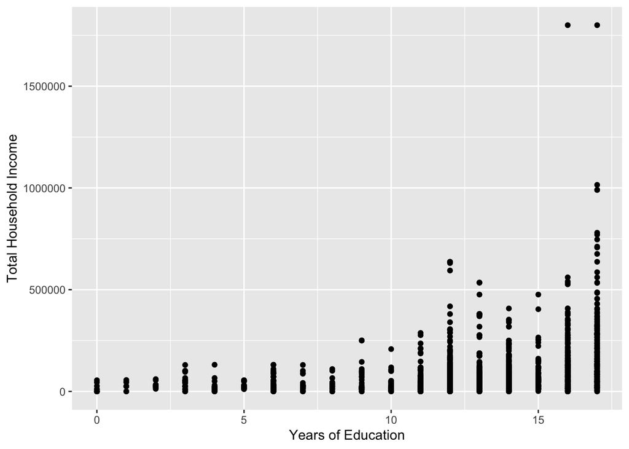

#### Part D: A line plot of the same two variables

**WarningTask**

Now make the same plot of `ed` vs. `income`, but use `geom_smooth()` instead of `geom_point()` to show the overall trend as a line. Assign the plot to `hrs_08_plot_smooth` and display it.

**Answer:**

Not given.

#### Part E: A boxplot of a categorical and a continuous variable

**WarningTask**

Create a plot of `act_vig` (vigorous physical activity frequency, x-axis) vs. `income` (y-axis) from `hrs_data` using `geom_boxplot()`. Assign it to `hrs_09_plot_box`.

**Answer:**

Start with something like:

```r
hrs_09_plot_box <- ggplot(hrs_data, aes(x = ______, y = ______)) +
  geom_boxplot()
```

#### Part F: Layer jitter on top

**WarningTask**

Starting from the same mapping, add a `geom_jitter()` layer on top of the boxplot layer so you can see the individual data points as well. Set `alpha = 0.2` inside `geom_jitter()` so the points don’t overwhelm the boxplot. Assign the result to `hrs_10_plot_box_jitter`.

**Answer:**

Not given.

#### Part G: Setting an aesthetic

**WarningTask**

Create a plot of `cond_count` (x-axis) vs. `act_vig` (y-axis) using `geom_jitter()`, and set the color of the points to `"darkblue"` (this goes *outside* of `aes()`). Also set `alpha` lower so the individual dots show up better where they overlap. Assign the plot to `hrs_11_plot_color_set`.

**Answer:**

Start with something like:

```r
hrs_11_plot_color_set <- ggplot(hrs_data, aes(x = _______, y = ______)) +
  geom_jitter(color = ______, alpha = ______)
```

#### Part H: Mapping an aesthetic

**WarningTask**

Now recreate the same plot, but this time map `color` to the `smoke_ever` variable *inside* `aes()` instead of setting a fixed color. Also set `alpha` lower so the dots show up better. Assign the plot to `hrs_12_plot_color_map`.

In 1-2 sentences, explain the difference between setting an aesthetic outside `aes()` and mapping it inside `aes()`.

**Answer:**

Not given.

### Question 3: Design choices for labels, facets, and themes

In Lesson 33, we covered how to polish a plot using `labs()`, `facet_wrap()`/`facet_grid()`, `theme()`, and how to save a finished plot with `ggsave()`.

#### Part A: Labels

**WarningTask**

Starting from `hrs_10_plot_box_jitter` (Question 2 Part F), add a `labs()` layer with an x-axis label, a y-axis label, and a title of your choice. Assign the result to `hrs_13_plot_labs` and display it.

**Answer:**

Not given.

#### Part B: Facets

**WarningTask**

Using `hrs_data`, create a histogram of `age_yr`, faceted by `sex` with `facet_wrap()`. Assign the result to `hrs_14_plot_facet`.

Looking at the faceted plot, does the age distribution appear to differ between males and females?

**Answer:**

Your plot should look like this:

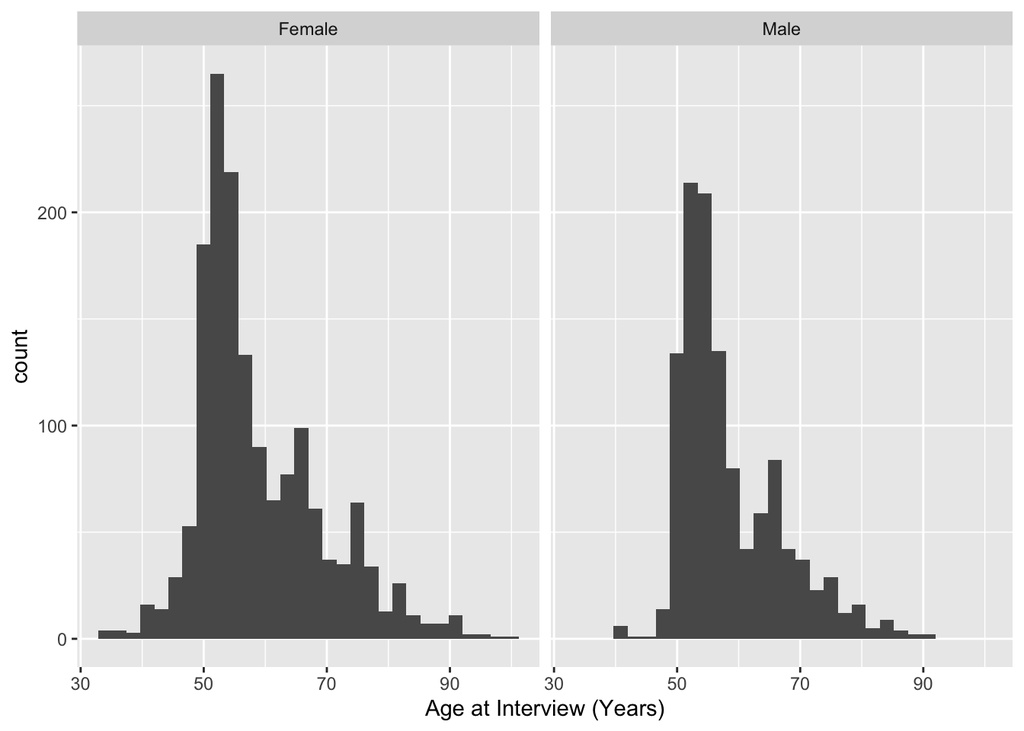

#### Part C: Color

**WarningTask**

Recreate the same distribution as `hrs_14_plot_facet` (a histogram of `age_yr`), but this time show the comparison by mapping `fill` to `sex` instead of faceting. Assign the result to `hrs_15_plot_fill` and display it.

Which approach, facet or fill, feels more appropriate for comparing the age distributions of males and females here? Why?

**Answer:**

Not given.

#### Part D: Themes

**WarningTask**

Take `hrs_13_plot_labs` from Part A and add a complete theme of your choice (e.g., `theme_minimal()`, `theme_bw()`, or `theme_classic()`). Then, use `theme()` to additionally increase the size of the plot title to `16`. Assign the final plot to `hrs_16_plot_final` and display it.

**Answer:**

Not given.

#### Part E: Saving your plot

**WarningTask**

Use `ggsave()` to save `hrs_16_plot_final` as a `.png` file into your `images` folder (use `here()` to build the file path). Set the width to `6` inches, the height to `4` inches, and the `dpi` to `200`.

**Answer:**

Start with something like:

```r
ggsave(
  filename = here(______, ______),
  plot = ______,
  width = ______,
  height = ______,
  units = "in",
  dpi = ______
)
```

#### Part F: Insert your saved plot

**WarningTask**

In a text section of your document (not a code chunk), insert the image you just saved in Part E using Markdown image syntax.

**Answer:**

Not given.